```python
from IPython.display import display, HTML

display(HTML("""
<style>
    /* 1. UMUMIY KONTEYNER VA SHRIFT */
    .rendered_html, .jp-RenderedHTMLCommon, .jp-RenderedMarkdown {
        font-family: "Times New Roman", Times, serif !important;
        color: black !important;
        font-feature-settings: "kern" 1, "liga" 1, "clig" 1, "dlig" 1 !important;
        -webkit-font-smoothing: antialiased !important;
    }

    /* 2. MATNLAR: 1.5 oraliq, abzats va ro‘yxatlar */
    .rendered_html p, .jp-RenderedHTMLCommon p {
        font-family: "Times New Roman", Times, serif !important;
        font-size: 14pt !important;
        line-height: 1.5 !important;
        text-align: justify !important;
        text-indent: 1.25cm !important; /* Faqat p uchun abzats */
        margin: 0 !important;
    }

    /* Ro‘yxatlar uchun maxsus (nuqtalarni qaytarish) */
    .rendered_html ul, .jp-RenderedHTMLCommon ul {
        list-style-type: disc !important;
        margin-left: 2.5cm !important; /* Nuqtalar ko‘rinishi uchun surish */
        padding: 0 !important;
        text-indent: 0 !important;
    }

    .rendered_html li, .jp-RenderedHTMLCommon li {
        display: list-item !important; /* Block-dan list-item-ga qaytarish */
        font-family: "Times New Roman", Times, serif !important;
        font-size: 14pt !important;
        line-height: 1.5 !important;
        text-indent: 0 !important;
        margin: 0 !important;
    }

    .rendered_html p, .jp-RenderedHTMLCommon p {
        text-indent: 1.25cm !important;
    }

    /* 3. SARLAVHALAR: Markazda */
    .rendered_html h1, .jp-RenderedHTMLCommon h1,
    .rendered_html h2, .jp-RenderedHTMLCommon h2,
    .rendered_html h3, .jp-RenderedHTMLCommon h3 {
        font-family: "Times New Roman", Times, serif !important;
        text-align: center !important;
        text-indent: 0 !important;
        margin: 0.5em 0 !important;
        font-weight: bold !important;
    }

    /* 4. KOD BLOKLARI VA PROMPTLARNI (In/Out) YASHIRISH */
    :root {
        --jp-code-font-size: 12pt !important;
    }

    /* "In [ ]" va "Out [ ]" yozuvlarini butunlay yo‘qotish */
    .jp-InputPrompt, .jp-OutputPrompt, .prompt, .input_prompt, .output_prompt {
        display: none !important;
        width: 0 !important;
        visibility: hidden !important;
    }

    /* Kod bloklarini chap chekkaga taqash */
    .jp-CodeCell .jp-Cell-inputWrapper, .cell.code_cell .input {
        margin-left: 0 !important;
        padding-left: 0 !important;
    }

    /* Sliderni yo‘qotish va qatorni majburan sindirish */
    .jp-CodeMirror, .CodeMirror, .CodeMirror-scroll, .CodeMirror-sizer, .CodeMirror-lines,
    .jp-OutputArea-output pre, .output_area pre,
    .CodeMirror-code, .CodeMirror-line,
    code, kbd, samp {
        font-family: "Consolas", monospace !important;
        font-size: 12pt !important;
        text-indent: 0 !important;
        line-height: 1.3 !important;
        white-space: pre-wrap !important;
        word-wrap: break-word !important;
        word-break: break-all !important;
        overflow-x: visible !important;
        height: auto !important;
    }

    /* 5. BIRINCHI KATAKCHANI YASHIRISH VA TANLANGANDA OCHISH */
    /* Odatiy holatda mutlaqo yashirin va umuman joy egallamaydi */
    .jp-Notebook .jp-Cell:first-child:not(.jp-mod-selected),
    .container div.cell.code_cell:first-of-type:not(.selected) {
        position: absolute !important;
        height: 0 !important;
        min-height: 0 !important;
        width: 0 !important;
        margin: 0 !important;
        padding: 0 !important;
        border: none !important;
        overflow: hidden !important;
        opacity: 0 !important;
        pointer-events: none !important;
        visibility: hidden !important;
    }

    /* Katakcha tanlanganda (Ctrl+A bosilganda) to‘liq ochiladi */
    .jp-Notebook .jp-Cell:first-child.jp-mod-selected,
    .container div.cell.code_cell:first-of-type.selected {
        position: relative !important;
        height: auto !important;
        width: 100% !important;
        opacity: 1 !important;
        overflow: visible !important;
        pointer-events: auto !important;
        visibility: visible !important;
    }
</style>
"""))
```

# 1. NumPy asoslari va Bir o‘lchovli massivlar (1D Arrays)

**NumPy nima?** NumPy — bu ma’lumotlar fani (Data Science) va ilmiy hisoblashlarda keng qo‘llaniladigan kutubxona bo‘lib, u juda ko‘p foydali funksiyalarga ega. Uning asosiy afzalliklari oddiy Python ro‘yxatlariga (lists) nisbatan ancha **yuqori tezlik** va **xotiradan tejamkorlik** hisoblanadi. Shuningdek, NumPy mashhur Pandas kutubxonasining asosi hamdir.

**Reja:**

1. NumPy asoslari va massiv yaratish
2. Indekslash va qirqish (Slicing)
3. Asosiy operatsiyalar (Vektor amallari)
4. Universal funksiyalar (Universal functions)

## 1. NumPy asoslari va Massiv yaratish

Oddiy Python ro‘yxati (list) turli ma’lumotlarni saqlash imkonini beradi. Har bir element o‘z indeksiga ega bo‘lib, ular `0` dan boshlanadi.

[figure not shown]

1-rasm. Python ro‘yxatlarida (list) elementlarning indekslanishi.

NumPy massivi (`ndarray`) ham xuddi shunga o‘xshaydi, lekin u odatda belgilangan o‘lchamga ega bo‘ladi va uning barcha elementlari **bir xil ma’lumot turida** (masalan, faqat butun sonlar - `integer` yoki haqiqiy sonlar - `float`) bo‘lishi kerak.

[figure not shown]

2-rasm. NumPy massivlarida elementlarning indekslanishi.

NumPy kutubxonasini ishlatish uchun avval uni chaqirib olamiz:

```python
import numpy as np
```

Python ro‘yxatini NumPy massiviga aylantirish (Casting):

```python
# Oddiy Python ro‘yxati
my_list = [0, 1, 2, 3, 4]

# Ro‘yxatni NumPy massiviga aylantirish
a = np.array(my_list)
print("Massiv:", a)
```

```
Massiv: [0 1 2 3 4]
```

### Massiv atributlarini tekshirish

Massiv haqida ma’lumot olish uchun bir qator atributlardan foydalanamiz:

```python
# Obyekt turini tekshirish
print("Obyekt turi:", type(a)) # Natija: numpy.ndarray

# Elementlarning ma’lumot turini tekshirish
# (Masalan: 64-bitli butun son)
print("Elementlar turi:", a.dtype) # Natija: int64

# Massivdagi elementlar soni
print("Elementlar soni (size):", a.size) # Natija: 5

# Massivning o‘lchovlar soni (Rank/Dimension)
print("O‘lchovlar soni (ndim):", a.ndim) # Natija: 1

# Massivning shakli (Tuple ko‘rinishida)
print("Massiv shakli (shape):", a.shape) # Natija: (5,)
```

```
Obyekt turi: <class 'numpy.ndarray'>
Elementlar turi: int64
Elementlar soni (size): 5
O‘lchovlar soni (ndim): 1
Massiv shakli (shape): (5,)
```

Xuddi shunday, biz haqiqiy sonlardan (float) iborat massivlarni ham yaratishimiz mumkin:

```python
b = np.array([3.1, 11.02, 6.2, 213.2, 5.2])
print("Elementlar turi:", b.dtype) # Natija: float64
```

```
Elementlar turi: float64
```

## 2. Indekslash va Qirqish (Indexing and Slicing)

Ro‘yxatlardagi kabi, NumPy massivlarida ham elementlarga murojaat qilish va ularni o‘zgartirish kvadrat qavslar `[]` yordamida amalga oshiriladi.

### Qiymatlarni o‘zgartirish:

```python
c = np.array([20, 1, 2, 3, 4])

# Birinchi elementni (0-indeks) 100 ga o‘zgartirish
c[0] = 100
print("O‘zgartirilgan massiv:", c) # Natija: [100, 1, 2, 3, 4]

# Beshinchi elementni (4-indeks) 0 ga o‘zgartirish
c[4] = 0
print("O‘zgartirilgan massiv:", c) # Natija: [100, 1, 2, 3, 0]
```

```
O‘zgartirilgan massiv: [100   1   2   3   4]
O‘zgartirilgan massiv: [100   1   2   3   0]
```

### Qirqish (Slicing):

Biz massivning ma’lum bir qismini kesib olib, yangi massivga o‘zlashtirishimiz mumkin. Indeks `[boshlanish:tugash]` shaklida beriladi va “tugash” indeksi hisobga olinmaydi.

```python
# 1-indeksdan boshlab 3-indeksgacha (4 kirmaydi) kesib olish
d = c[1:4]
print("Qirqilgan massiv:", d) # Natija: [1, 2, 3]

# Massivning bir nechta elementini birdaniga o‘zgartirish
c[3:5] = 300, 400
print("Yangi qiymatlar bilan massiv:", c)
# Natija: [100, 1, 2, 300, 400]
```

```
Qirqilgan massiv: [1 2 3]
Yangi qiymatlar bilan massiv: [100   1   2 300 400]
```

## 3. Asosiy Operatsiyalar (Vektor amallari)

NumPy matematik amallarni bajarishni juda osonlashtiradi. Oddiy Python bilan sikl (`for`) yordamida ko‘p qatorli kod yozish o‘rniga, NumPy’da buni bir qatorda, hamda juda tez amalga oshirish mumkin. Keling, bu amallarni Evklid vektorlari misolida ko‘rib chiqamiz.

### Vektorlarni qo‘shish va ayirish ($z = u \pm v$)

```python
u = np.array([1, 0])
v = np.array([0, 1])

# Vektorlarni qo‘shish
z_add = u + v
print("Qo‘shish natijasi:", z_add) # Natija: [1, 1]

# Vektorlarni ayirish
z_sub = u - v
print("Ayirish natijasi:", z_sub) # Natija: [1, -1]
```

```
Qo‘shish natijasi: [1 1]
Ayirish natijasi: [ 1 -1]
```

*(Izoh: Agar buni oddiy Pythonda qilsak, har bir element uchun sikl aylantirishga to‘g‘ri kelardi. NumPy esa buni to‘g‘ridan-to‘g‘ri barcha elementlarga qo‘llaydi, bu kattaroq o‘lchamdagi datalarda o‘ta yuqori unumdorlikni beradi).*

### Skalyarga ko‘paytirish (Array multiplication with a scalar)

Vektorni biron-bir doimiy songa ko‘paytirganda, uning har bir elementi shu songa ko‘paytiriladi.

```python
y = np.array([1, 2])
z = 2 * y
print("Skalyarga ko‘paytirish:", z) # Natija: [2, 4]
```

```
Skalyarga ko‘paytirish: [2 4]
```

### Ikki massivning Hadamard ko‘paytmasi (Element-wise product)

Bunda ikkita massivning mos indeksdagi elementlari bir-biriga ko‘paytiriladi.

```python
u = np.array([1, 2])
v = np.array([3, 2])

z = u * v
print("Hadamard ko‘paytmasi:", z) # Natija: [3, 4] (1*3 va 2*2)
```

```
Hadamard ko‘paytmasi: [3 4]
```

### Nuqtali ko‘paytma (Dot product)

Nuqtali ko‘paytma — bu mos elementlarni ko‘paytirib, so‘ngra ularning yig‘indisini hisoblash demakdir. Buni `np.dot()` funksiyasi yordamida bajaramiz: $u^T v$.

```python
u = np.array([1, 2])
v = np.array([3, 1])

result = np.dot(u, v)
print("Nuqtali ko‘paytma:", result) # Natija: 5 (1*3 + 2*1)
```

```
Nuqtali ko‘paytma: 5
```

### Massivga konstanta qo‘shish (Broadcasting)

Agar massivga bitta butun son qo‘shilsa, NumPy bu sonni avtomatik ravishda massivning **har bir elementiga** qo‘shib chiqadi. Bu xususiyat **Broadcasting** deb ataladi.

```python
u = np.array([1, 2, 3, -1])
z = u + 1
print("Broadcasting natijasi:", z) # Natija: [2, 3, 4, 0]
```

```
Broadcasting natijasi: [2 3 4 0]
```

## 4. Universal Funksiyalar va Grafik chizish

NumPy massivlari ustida ishlovchi ko‘plab tayyor matematik funksiyalar mavjud.

### Asosiy statistik va matematik funksiyalar

```python
a = np.array([1, -1, 1, -1])

# O‘rtacha qiymatni hisoblash
mean_a = a.mean()
print("O‘rtacha qiymat:", mean_a) # Natija: 0.0

b = np.array([1, -2, 3, 4, 5])

# Maksimal qiymatni topish
max_b = b.max()
print("Eng katta element:", max_b) # Natija: 5

# Pi qiymatidan foydalanish
print("Pi qiymati:", np.pi)
```

```
O‘rtacha qiymat: 0.0
Eng katta element: 5
Pi qiymati: 3.141592653589793
```

### Massivlarga matematik funksiyalarni qo‘llash (Masalan: sinus)

Biz butun bir massiv elementlariga bitta funksiyani birdaniga qo‘llashimiz mumkin:

```python
# Radianlarda massiv yaratamiz
x = np.array([0, np.pi/2, np.pi])

# Har bir elementning sinusini hisoblaymiz
y = np.sin(x)
print("Sinus qiymatlari:", y)
# Natija: [0.0, 1.0, 0.0] ga yaqin qiymatlar
```

```
Sinus qiymatlari: [0.0000000e+00 1.0000000e+00 1.2246468e-16]
```

### `linspace` funksiyasi

`np.linspace(start, stop, num)` ma’lum bir oraliqda tekis taqsimlangan raqamlar ketma-ketligini yaratish uchun juda qulay funksiyadir.

```python
# -2 dan 2 gacha bo‘lgan oraliqda jami 5 ta nuqta yaratish
np.linspace(-2, 2, num=5)
# Natija: array([-2., -1.,  0.,  1.,  2.])

# Xuddi shu oraliqda 9 ta nuqta yaratish
np.linspace(-2, 2, num=9)
# Natija: array([-2. , -1.5, -1. , -0.5,  0. ,  0.5,  1. ,  1.5,  2. ])
```

```
array([-2. , -1.5, -1. , -0.5,  0. ,  0.5,  1. ,  1.5,  2. ])
```

## 5. Matematik funksiyalarni grafikda tasvirlash (Plotting)

`linspace` yordamida funksiyalar grafigini osongina chizish mumkin. Buning uchun `matplotlib` kutubxonasidan foydalanamiz. Jupyter Notebook’da grafikni to‘g‘ridan-to‘g‘ri ko‘rish uchun `%matplotlib inline` sehrli (magic) buyrug‘ini yozish tavsiya etiladi.

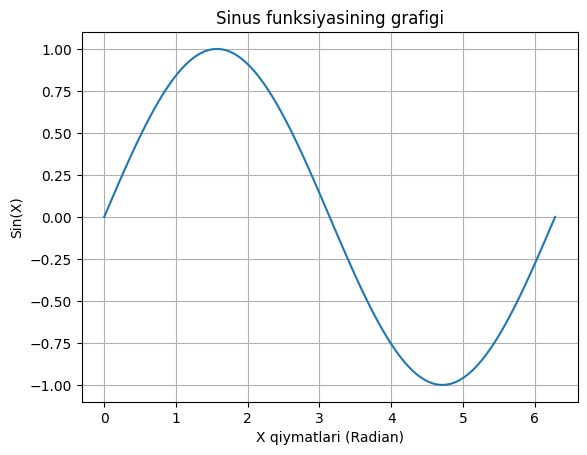

```python
# Grafik chizish uchun kutubxonani chaqiramiz
import matplotlib.pyplot as plt
%matplotlib inline

# 0 dan 2*Pi gacha bo‘lgan oraliqda
# 100 ta nuqta yaratamiz (X o‘qi uchun)
x = np.linspace(0, 2*np.pi, 100)

# Har bir X nuqtasi uchun Sinus qiymatini hisoblaymiz (Y o‘qi uchun)
y = np.sin(x)

# Grafikni chizish
plt.plot(x, y)
plt.title("Sinus funksiyasining grafigi")
plt.xlabel("X qiymatlari (Radian)")
plt.ylabel("Sin(X)")
plt.grid(True)
plt.show()
```

Ushbu amallar NumPy kutubxonasining naqadar kuchli va foydali ekanligini ko‘rsatadi. Bu ma’lumotlar fani, sun’iy intellekt va muhandislik hisob-kitoblarida ma’lumotlarni qayta ishlashning asosiy tayanchlaridan biri hisoblanadi.

*Qo‘shimcha misollar va laboratoriya ishlari uchun numpy.org saytiga murojaat qiling.*